# Project7_Image_classification_CNN

**Project 7: Image classification using CNNs for crop seediling**

Author: Jinad Patel

Email: jinadpatel@gmail.com

# **Context:**

Can you differentiate a weed from a crop seedling?

The ability to do so effectively can mean better crop yields and better stewardship of the environment.

The Aarhus University Signal Processing group, in collaboration with University of Southern Denmark, has recently released a dataset containing images of unique plants belonging to 12 species at several growth stages

# Objective:

To implement the techniques learnt as a part of the course

```python
from google.colab import drive
```

```python
drive.mount('/content/drive')
```

## 1. Import the libraries, load dataset, print shape of data, visualize the images in dataset. (5 Marks)

```python
# Ignore Warnings
import warnings
warnings.filterwarnings("ignore")

# Import the necessary libraries

import numpy as np
import pandas as pd
import cv2
import time
import copy

# Import visualization libraries
import seaborn as sns
import matplotlib.pyplot as plt
import matplotlib.image as matimg
%matplotlib inline
sns.set_color_codes("dark")

# Tensorflow imports
import tensorflow as tf
from tensorflow.keras import optimizers, losses
from tensorflow.keras.layers import Conv2D, Dropout, MaxPooling2D, Flatten, Activation, BatchNormalization,Dense
from tensorflow.keras.models import Sequential
from tensorflow.math import confusion_matrix
from tensorflow.keras.callbacks import Callback
from tensorflow.keras.preprocessing.image import ImageDataGenerator
from tensorflow.keras.metrics import Recall, Precision
from tensorflow.keras.callbacks import ModelCheckpoint, EarlyStopping


# Sklearn required imports
from sklearn.model_selection import train_test_split
from sklearn.preprocessing import OneHotEncoder

# Constants
SEED=42
```

```python
# Adjust pandas display and formatting settings

# Remove scientific notations and display numbers with 2 decimal points instead
pd.options.display.float_format = '{:,.2f}'.format

# Increase cell width
from IPython.core.display import display, HTML
display(HTML("<style>.container { width:98% !important; }</style>"))

# Update default style and size of charts
plt.style.use('ggplot')
plt.rcParams['figure.figsize'] = [20, 15]

# Increase max number of rows and columns to display in pandas tables
pd.set_option('display.max_columns', 500)
pd.set_option('display.max_rows', 500)
```

```python
# Load Dataset
images_loc = r'/content/drive/My Drive/Project7_Data/images.npy'
labels_loc = r'/content/drive/My Drive/Project7_Data/Labels.csv'

imgs = np.load(images_loc)
df_labels = pd.read_csv(labels_loc)

# Print shape of the data{
print("Number of Images: {0}, Shape: {1}, Channels: {2}".format(imgs.shape[0],imgs.shape[1:3], imgs.shape[3]))
print("Labels shape: {0}".format(len(df_labels)))
```

```
Number of Images: 4750, Shape: (128, 128), Channels: 3
Labels shape: 4750
```

### Observations

There are 4750 images available in the data set of the size 128x128x3. All the images are color images.

```python
# See the number of classes available and their counts
print("Number of classes:")
df_labels.value_counts()
```

```
Number of classes:
```

```
Label
Loose Silky-bent             654
Common Chickweed             611
Scentless Mayweed            516
Small-flowered Cranesbill    496
Fat Hen                      475
Charlock                     390
Sugar beet                   385
Cleavers                     287
Black-grass                  263
Shepherds Purse              231
Maize                        221
Common wheat                 221
dtype: int64
```

### Observations:

There are 12 classes with the images of each type roughly ranges between 200 to 700. We have less amount ofimages available for Maize and Common Wheat type. This might lead us to poor performace in prediction.

```
['Black-grass', 'Charlock', 'Cleavers', 'Common Chickweed', 'Common wheat', 'Fat Hen', 'Loose Silky-bent', 'Maize', 'Scentless Mayweed', 'Shepherds Purse', 'Small-flowered Cranesbill', 'Sugar beet']
```

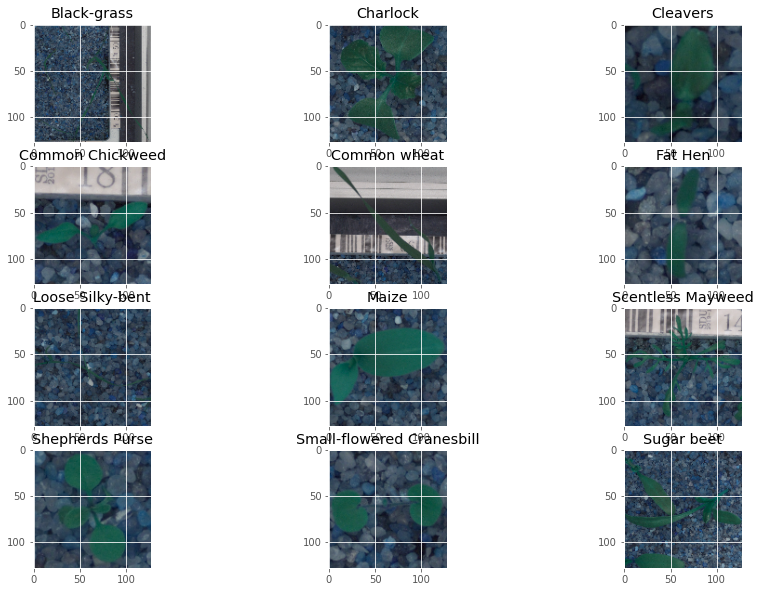

```python
# Image Visualization

# Prepare the sorted list of lables

labels = sorted(df_labels['Label'].unique())
print(labels)
labels_indexes = [min(df_labels[df_labels.Label == label].index) for label in labels]
images_per_category = [imgs[index] for index in labels_indexes]

plt.gcf().set_size_inches(15,10)
for idx, (img, lbl) in enumerate(zip(images_per_category, labels)):
  splot = plt.subplot(4,3,idx+1)
  plt.title(lbl)
  plt.imshow(img)
```

### Observations:

From above images, we can see the different class of images being displayed. We see that all the images are having different backgrounds or some has pebbles and some has measure tape in the background. These are the good quality images.

Each seedlings are having same color, green. We can take advantage of this to improve our model performace later.

## 2. Data Pre-processing: (15 Marks)

1. Normalization
2. Gaussian Blurring
3. Visualization after the pre-processsing

```python
# As we have seen above, before we process the image, we should get the cleaner representation of the image. In other words, the noise should be removed from the images.
# Here we will suppress the background and focus on the plant only. To achieve this, we can extrcat the green region from the image that only represents the plant itself.
# I am assuming no background contains green color and this will help us get the clear representation of the plants only and make accurate predictions.

# Define helper function that pre process the image and get rid of the background

def process_extract_images(img):
  # Initialize Gaussian Blurring
  gblur = cv2.GaussianBlur(img, (5,5), 0)

  # Steps teaken to extract green color from the image
  # 1. Get the image in the hsv format
  # 2. Since Green color hue ranges from 24 to 76, we will use this values as start and end to determine right color spectrum
  # 3. Select the pixels only greater than 0 (represents only green region)
  # 4. Use the above mast to retrirve green image

  hsv_format = cv2.cvtColor(gblur, cv2.COLOR_BGR2HSV)
  start_green = (24,40,40)
  end_green = (76,255,255)
  green_mask = cv2.inRange(hsv_format,start_green,end_green)

  finalImg = np.zeros_like(img, np.uint8)
  finalImg[green_mask > 0] = img[green_mask > 0]
  return finalImg
```

```python
# Process images and get the without background and Gaussian blurred images
processedImgs = []
for img in imgs:
  processed = process_extract_images(img)
  processedImgs.append(processed)

# Normalize the processed images
# Change the data type to float as we will be dividing by 255
processedImgs = np.asarray(processedImgs, dtype=np.float32)
processedImgs /= 255.0
```

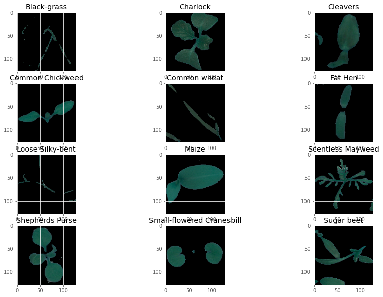

```python
# Visualize processed image for each category
processed_images_per_category = [processedImgs[index] for index in labels_indexes]
plt.gcf().set_size_inches(15,10)
for idx, (img, lbl) in enumerate(zip(processed_images_per_category, labels)):
  splot = plt.subplot(4,3,idx+1)
  plt.title(lbl)
  plt.imshow(img)
```

## 3. Make data compatible: (10 Marks)

- Convert labels to one-hot-vectors.
- Print the label for y_train[0].
- Split the dataset into training, testing, and validation set. (Hint: First split images and labels into training and testing set with test_size = 0.3. Then further split test data into test and validation set with test_size = 0.5)
- Check the shape of data, Reshape data into shapes compatible with Keras models if it’s not already. If it’s already in the compatible shape, then comment in the notebook that it’s already in compatible shape.

```python
# Convert labels to one-hot-vectors

encoder = OneHotEncoder(handle_unknown='ignore')
encoded_labels = encoder.fit_transform(df_labels).toarray()

print("OneHotEncoded Labels Shape: {}".format(encoded_labels.shape))
```

```
OneHotEncoded Labels Shape: (4750, 12)
```

```python
# Visualize the One hot encoded labels.
# Since we have 12 classes, we should see 12 columns and respected one for each class.
for cat, idx in zip(encoder.categories_[0], labels_indexes):
  print('{0:20}\t{1}'.format(cat, encoded_labels[idx]))
```

```
Black-grass         	[1. 0. 0. 0. 0. 0. 0. 0. 0. 0. 0. 0.]
Charlock            	[0. 1. 0. 0. 0. 0. 0. 0. 0. 0. 0. 0.]
Cleavers            	[0. 0. 1. 0. 0. 0. 0. 0. 0. 0. 0. 0.]
Common Chickweed    	[0. 0. 0. 1. 0. 0. 0. 0. 0. 0. 0. 0.]
Common wheat        	[0. 0. 0. 0. 1. 0. 0. 0. 0. 0. 0. 0.]
Fat Hen             	[0. 0. 0. 0. 0. 1. 0. 0. 0. 0. 0. 0.]
Loose Silky-bent    	[0. 0. 0. 0. 0. 0. 1. 0. 0. 0. 0. 0.]
Maize               	[0. 0. 0. 0. 0. 0. 0. 1. 0. 0. 0. 0.]
Scentless Mayweed   	[0. 0. 0. 0. 0. 0. 0. 0. 1. 0. 0. 0.]
Shepherds Purse     	[0. 0. 0. 0. 0. 0. 0. 0. 0. 1. 0. 0.]
Small-flowered Cranesbill	[0. 0. 0. 0. 0. 0. 0. 0. 0. 0. 1. 0.]
Sugar beet          	[0. 0. 0. 0. 0. 0. 0. 0. 0. 0. 0. 1.]
```

### Observations:

- As seen above, we have one hot encoded each classes and they are shown approproately.

```python
# Prepare data for the test_train_split

X = copy.deepcopy(processedImgs)
Y = copy.deepcopy(encoded_labels)

# Print the shape
print("X shape: {}".format(X.shape))
print("Y shape: {}".format(Y.shape))
```

```
X shape: (4750, 128, 128, 3)
Y shape: (4750, 12)
```

```python
# First split tarin/test with 30% data in the test
X_train, X_test, y_train, y_test = train_test_split(X, Y, test_size=0.30, random_state=SEED, stratify=Y)

# Then, further split test data into validation and test with 50% in the validation.
X_valid, X_test, y_valid, y_test = train_test_split(X_test, y_test, test_size=0.50, random_state=SEED, stratify=y_test)
```

```python
# Print the shape for all the splitted attributes
print("X Train Shape: ", X_train.shape)
print("Y Train Shape: ", y_train.shape)
print()
print("X Test Shape: ", X_test.shape)
print("Y Test Shape: ", y_test.shape)
print()
print("X Validation Shape: ", X_valid.shape)
print("Y Validation Shape: ", y_valid.shape)
print()
```

```
X Train Shape:  (3325, 128, 128, 3)
Y Train Shape:  (3325, 12)

X Test Shape:  (713, 128, 128, 3)
Y Test Shape:  (713, 12)

X Validation Shape:  (712, 128, 128, 3)
Y Validation Shape:  (712, 12)
```

### Observations:

- As seen above, Training set has 3325 images, each of the size 128x128x3
- Testing set has 713 images
- Validation set has 712 images
- All the outcome variable has 12 columns, as this is multi class problem.
- As size of the image is 128x128x3, which is acceptable shape for CNN model building, we **do not** need to reshape the data.

## 4. Building CNN: (15 Marks)

- Define layers.
- Set optimizer and loss function. (Use Adam optimizer and categorical crossentropy.)

```python
# Build model using Sequential API
model = Sequential()
model.add(Conv2D(32, 3, input_shape=(128,128,3), activation='relu'))
model.add(MaxPooling2D((2,2)))
model.add(Conv2D(64, 3, activation='relu'))
model.add(MaxPooling2D((2,2)))
model.add(Conv2D(128, 3, activation='relu'))
model.add(MaxPooling2D((2,2)))
model.add(Conv2D(256, 3, activation='relu'))
model.add(MaxPooling2D((2,2)))

# Flatten the data for the input to Dense network
model.add(Flatten())
model.add(BatchNormalization())

# Initialize Dense network
model.add(Dense(64, kernel_initializer='he_normal', use_bias=False))
model.add(BatchNormalization())
model.add(Activation('elu'))

model.add(Dense(32, kernel_initializer='he_normal', use_bias=False))
model.add(BatchNormalization())
model.add(Activation('elu'))

# Output layer with Softmax function
model.add(Dense(12, activation='softmax'))

# Optimizers
optmzr = optimizers.Adam(learning_rate=0.001)

model.compile(loss='categorical_crossentropy', optimizer=optmzr, metrics=['accuracy'])

model.summary()
```

```
Model: "sequential"
_________________________________________________________________
Layer (type)                 Output Shape              Param #
=================================================================
conv2d (Conv2D)              (None, 126, 126, 32)      896
_________________________________________________________________
max_pooling2d (MaxPooling2D) (None, 63, 63, 32)        0
_________________________________________________________________
conv2d_1 (Conv2D)            (None, 61, 61, 64)        18496
_________________________________________________________________
max_pooling2d_1 (MaxPooling2 (None, 30, 30, 64)        0
_________________________________________________________________
conv2d_2 (Conv2D)            (None, 28, 28, 128)       73856
_________________________________________________________________
max_pooling2d_2 (MaxPooling2 (None, 14, 14, 128)       0
_________________________________________________________________
conv2d_3 (Conv2D)            (None, 12, 12, 256)       295168
_________________________________________________________________
max_pooling2d_3 (MaxPooling2 (None, 6, 6, 256)         0
_________________________________________________________________
flatten (Flatten)            (None, 9216)              0
_________________________________________________________________
batch_normalization (BatchNo (None, 9216)              36864
_________________________________________________________________
dense (Dense)                (None, 64)                589824
_________________________________________________________________
batch_normalization_1 (Batch (None, 64)                256
_________________________________________________________________
activation (Activation)      (None, 64)                0
_________________________________________________________________
dense_1 (Dense)              (None, 32)                2048
_________________________________________________________________
batch_normalization_2 (Batch (None, 32)                128
_________________________________________________________________
activation_1 (Activation)    (None, 32)                0
_________________________________________________________________
dense_2 (Dense)              (None, 12)                396
=================================================================
Total params: 1,017,932
Trainable params: 999,308
Non-trainable params: 18,624
_________________________________________________________________
```

### Observations:

- Here all the parameters have been chosen after too many trials and best have been selected that yields best output.
- As seen above, I have used combination of COnvilution and Max pooling layer to create the CNN model.
- First Conv2D layer has 32 feature maps and applied to original image with 3x3 filter.
- The ideal approach of increasing feature maps is followed, this is used to make a gread trade off for reducing picture size because of pooling layer.
- Four Conv2D layers have been used that is followed by Dense network. Here , RELU activation function is being used.
- 2 Dense layer has been used to make Fully connected layer. First Dense layer has 64 neurons which would have input from preceeding Conv2D layer.
- Second Dense layer has 32 neurons.
- Each Dense layer is followed by BatchNormalization to normalize the picture intensity and then followed by Activation function ELU which yields best result.
- At last, Adam optimizer with learning rate of 0.001 is used and loss function is categorical_crossentropy is used as this is multi classification problem.

```python
# Early Stoppping and Model Checkpoint for the Model filt call backs

class CustomEarlyStopping(Callback):
    def __init__(self):
        super(CustomEarlyStopping, self).__init__()
        self.best_weights = None

    def on_train_begin(self, logs=None):
        # The epoch the training stops at.
        self.stopped_epoch = 0

        self.best_val_accuracy = 0.90
        self.best_accuracy = 0.90

    def on_epoch_end(self, epoch, logs=None):
        val_accuracy=logs.get('val_accuracy')
        acc=logs.get('accuracy')


        if np.greater(val_accuracy, self.best_val_accuracy) and np.greater(acc, self.best_accuracy):
            self.best_val_accuracy = val_accuracy
            self.best_accuracy = acc
            self.stopped_epoch = epoch
            self.model.stop_training = True
            # Record the best weights if current results is better (less).
            self.best_weights = self.model.get_weights()
        else:
            return

    def on_train_end(self, logs=None):
        if self.stopped_epoch > 0:
            print("Epoch %05d: early stopping" % (self.stopped_epoch + 1))
```

```python
# Image Data Generator

generator = ImageDataGenerator(rotation_range=180, width_shift_range=0.10, height_shift_range=0.10, zoom_range=0.15, horizontal_flip=True, vertical_flip=True)
generator.fit(X_train)
itr = generator.flow(X_train, y_train, batch_size=64)
```

## 5. Fit and evaluate model and print confusion matrix. (10 Marks)

```python
# Start Model Trainig
start = time.time()
fitter = model.fit(itr, epochs=60, validation_data=(X_valid, y_valid), callbacks=[CustomEarlyStopping()], verbose=True)
end = time.time()
print("Total duration: {0}". format(end-start))
```

```
Epoch 00027: early stopping
Total duration: 313.4330360889435
```

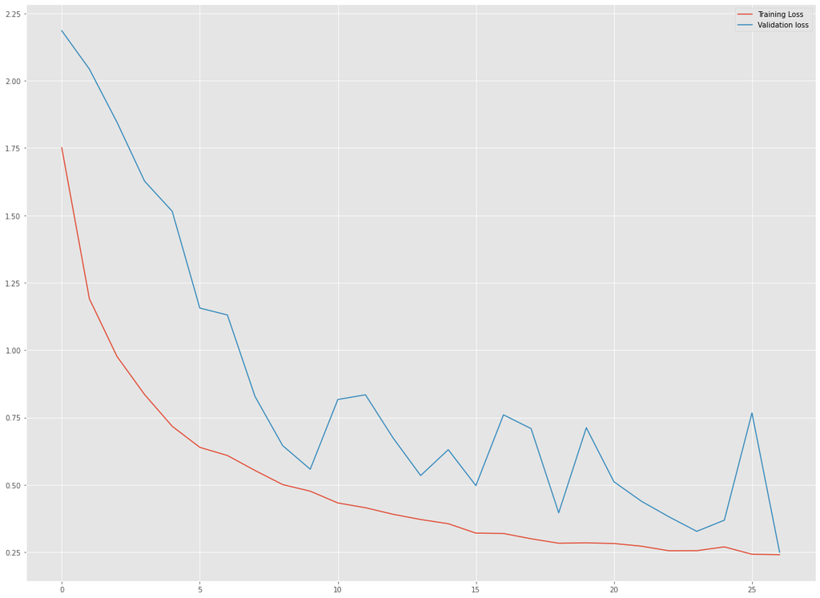

```python
# Plot Train and Validation loss

hist = pd.DataFrame(fitter.history)
plt.plot(hist['loss'])
plt.plot(hist['val_loss'])
plt.legend(("Training Loss", "Validation loss"))
```

```python
# Get Train and Test Accuracy
result = model.evaluate(X_train, y_train, batch_size=64, verbose=False)
print("Training Accuracy: ", result[1] * 100)
result = model.evaluate(X_test, y_test, batch_size=64, verbose=False)
print("Test Accuracy: ", result[1]*100)
```

```
Training Accuracy:  93.2330846786499
Test Accuracy:  92.14586019515991
```

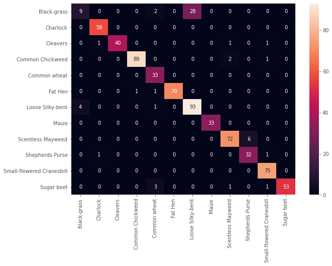

```python
# Get teh confusion matrix

y_pred = model.predict(X_test)

y_lbl_test = []
y_lbl_pred = []

for test, pred in zip(y_test, y_pred):
  y_lbl_test.append(np.argmax(test))
  y_lbl_pred.append(np.argmax(pred))
# Confusion Matrix
cm = confusion_matrix(y_lbl_test, y_lbl_pred)

df_cm = pd.DataFrame(np.asarray(cm), index = labels,
                     columns = labels)
plt.figure(figsize = (10,7))
sns.heatmap(df_cm, annot=True, fmt='d')
```

```python
# Calculate Recall and Precision
recall = Recall()
precision = Precision()

recall.update_state(y_test, y_pred)
precision.update_state(y_test, y_pred)

print("Recall: ", recall.result().numpy())
print("Precision: ", precision.result().numpy())
```

```
Recall:  0.91584855
Precision:  0.9275568
```

## 6. Visualize predictions for x_test[2], x_test[3], x_test[33], x_test[36], x_test[59]. (5 Marks)

```
Original Images
```

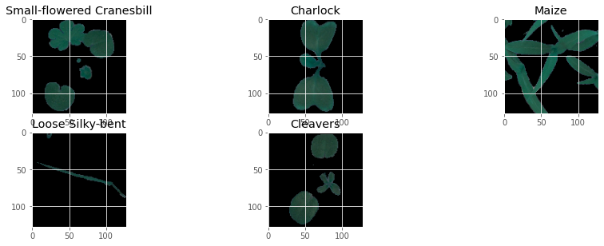

```python
visulaize_indexes = [2,3,33,36,59]

images_to_visualize = [X_test[idx] for idx in visulaize_indexes]

labels_test = [labels[np.argmax(y_test[idx])] for idx in visulaize_indexes]
print("Original Images\n")
plt.gcf().set_size_inches(15,10)
for idx, (img, lbl) in enumerate(zip(images_to_visualize, labels_test)):
  splot = plt.subplot(4,3,idx+1)
  plt.title(lbl)
  plt.imshow(img)
```

```
Prediction using the model on the test set
```

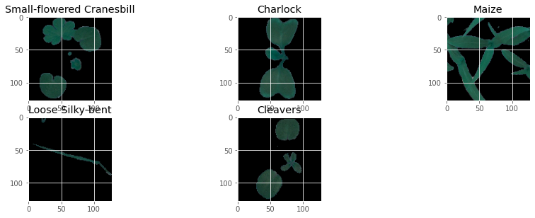

```python
print("Prediction using the model on the test set\n")
predicted = []
for idx in visulaize_indexes:
  img = np.expand_dims(np.asarray(X_test[idx]), 0)
  pred = model.predict(img)
  predicted.append(labels[np.argmax(pred)])
plt.gcf().set_size_inches(15,10)
for idx, (img, lbl) in enumerate(zip(images_to_visualize, predicted)):
  splot = plt.subplot(4,3,idx+1)
  plt.title(lbl)
  plt.imshow(img)
```

### Observations:

- From the above prediction on the test images at index 2,3,33,36,59 we see accurate prediction and all the plants are accurately identified.
- With the given setup we see the best performance here.